# Math 472/572 and Exploratory Data Analysis

February 8, 2022

```r
library(tidyverse)
library(dplyr)
```

# Exploratory Data Analysis (EDA)

Exploratory Data Analysis can be considered an iterative process or cycle in which we examine data to try to discover patterns, find anomalies, test hypotheses, and check assumptions. We can use the tools we’ve learned, namely visualization and transformation of data. We’ll go deeper into this in future weeks, but we have enough skills to try to do some of this now.

The author of our textbook suggests that EDA can follow the following cycle: 1. Generate questions about your data. 2. Search for answers by visualizing, transforming, and modeling your data. 3. Use what you learn to refine your questions and/or generate new questions.

The author of the text also says that the key to asking *quality* questions is to generate a large *quantity* of questions! Doing this takes practice. Practice I hope that will start in this class.

Given a new set of data, here are some questions you may ask: - What values are most common? Why? - What values are most rare? Why? - Does what I’m finding match my expectations? - Are there any unusual patters? If so, are there any explanations for these? - What type of variation occurs in my variables. - What type of covariation occurs between my variables.

```r
bodymeas <- read.csv("~/math472/class_week5/bodymeas.csv")
coasters <- read.csv("~/math472/class_week5/coasters.csv")
str(bodymeas)
```

```
'data.frame':   5967 obs. of  11 variables:
 $ id         : int  51624 51628 51629 51630 51633 51635 51643 51647 51648 51651 ...
 $ age        : int  34 60 26 49 80 80 42 45 28 19 ...
 $ gender     : chr  "Male" "Female" "Female" "Female" ...
 $ race       : chr  "Non-Hipanic White" "Non-Hipanic Black" "Mexican American" "Non-Hipanic White" ...
 $ marital    : chr  "Married" "Widowed" "Married" "Living with partner" ...
 $ weight     : num  87.4 116.8 97.6 86.7 79.1 ...
 $ height     : num  165 166 173 168 174 ...
 $ bmi        : num  32.2 42.4 32.6 30.6 26 ...
 $ upleglength: num  41.5 35.3 41.7 37.5 42.8 43 32.7 38 38.9 38.5 ...
 $ uparmlength: num  40 39 38.7 36.1 40 41.7 36.5 34.7 38 35.6 ...
 $ armcircumf : num  36.4 42.2 37 33.3 30.2 33.3 39.6 31.5 35.7 40.5 ...
```

```r
View(bodymeas)
str(coasters)
```

```
'data.frame':   408 obs. of  14 variables:
 $ state        : chr  "CA" "CA" "CA" "CA" ...
 $ country      : chr  "US" "US" "US" "US" ...
 $ steel        : int  1 1 1 1 1 1 1 1 0 1 ...
 $ construction : chr  "Steel" "Steel" "Steel" "Steel" ...
 $ height       : num  32 NA 35.5 35.5 NA ...
 $ speed        : num  81 45.4 76.1 76.1 89.1 ...
 $ length       : num  823 814 285 285 1851 ...
 $ inversions   : chr  "Yes" "No" "Yes" "Yes" ...
 $ numinversions: int  5 0 3 3 1 0 0 0 0 3 ...
 $ duration     : num  120 NA 108 168 156 NA NA NA 150 92 ...
 $ gforce       : num  4 NA 5.2 6.2 NA NA NA NA 3.2 4.5 ...
 $ opened       : int  1994 1979 1990 1998 2001 1999 2004 2000 1978 2001 ...
 $ region       : int  1 1 1 1 1 1 1 1 1 1 ...
 $ continent    : chr  "North America" "North America" "North America" "North America" ...
```

```r
View(coasters)
```

## Visualizing Distributions

### Single Variable - Categorical

What can you say about marital status of the individuals included in our `bodymeas` data set?

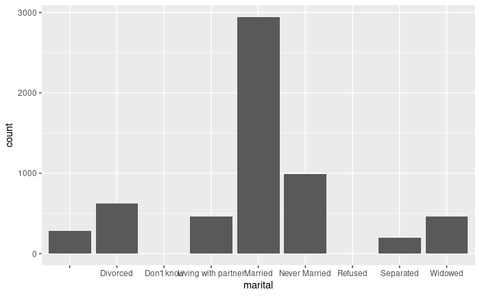

```r
ggplot(bodymeas) + geom_bar(aes(x = marital)) # very cluttered x-axis
```

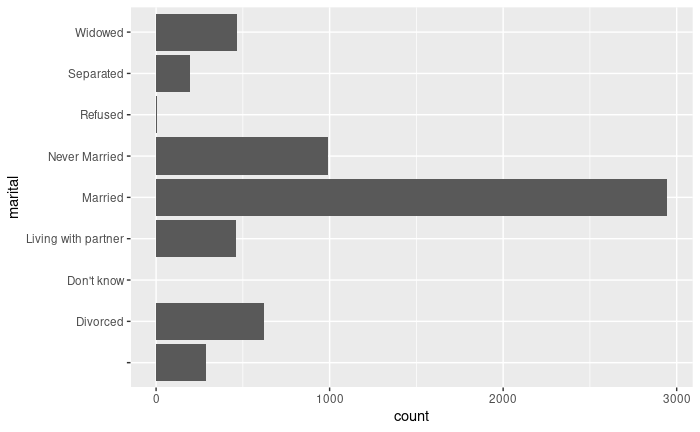

```r
ggplot(bodymeas) + geom_bar(aes(y = marital))
```

Can you find the exact counts of each type of marital status given?

```r
bodymeas %>% group_by(marital) %>% summarize(num = n())
```

| marital | num |
| --- | --- |
|  | 285 |
| Divorced | 624 |
| Don't know | 1 |
| Living with partner | 462 |
| Married | 2945 |
| Never Married | 988 |
| Refused | 3 |
| Separated | 194 |
| Widowed | 465 |

Can you generate a chart using this chart/data frame?

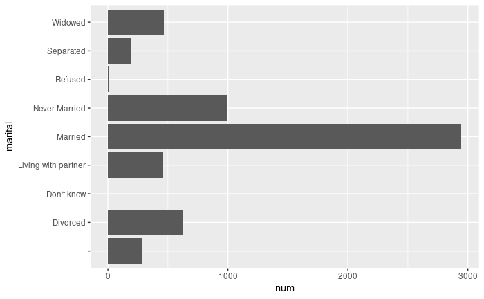

```r
o <- bodymeas %>% group_by(marital) %>% summarize(num = n())
ggplot(o) + geom_col(aes(x = num, y = marital))
```

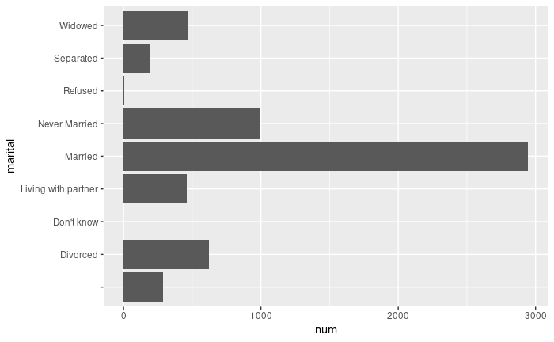

```r
# or equivalently
ggplot(o) + geom_bar(aes(x = num, y = marital), stat = "identity")
```

### Single Variable - Numerical

Play with different numerical variables, such as `weight` or `height` to see what you can tell about the values? Which are most common? Are there any patterns? Does this match our expectations?

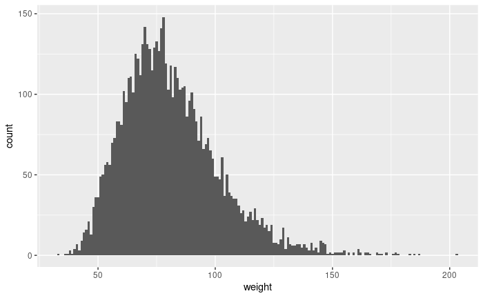

```r
ggplot(bodymeas) + geom_histogram(aes(x = weight), binwidth = 1)
```

Compare what you get using `geom_histogram()`, `geom_freqpoly()`, and `geom_density()`. How can you change bin widths and does doing so change what we say about the data?

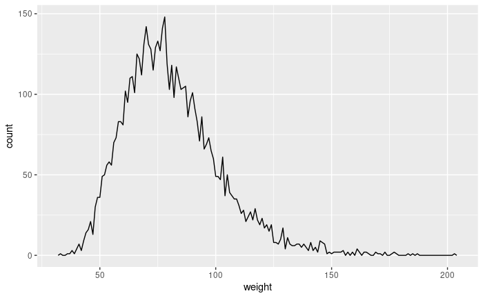

```r
ggplot(bodymeas) + geom_freqpoly(aes(x = weight), binwidth = 1)
```

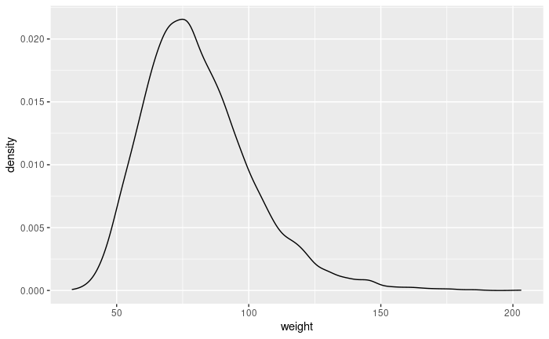

```r
ggplot(bodymeas) + geom_density(aes(x = weight))
```

In addition to filtering data to look at subgroups, we can also consider adjusting our $x$ or $y$ axes using `coord_cartesian(xlim = c(xmin,xmax))` or similarly for our $y$-axes values.

What if you use a boxplot and break this up by marital status or race? We can also rearrange the order in which the individual boxplots occur by using the `reorder()` function.

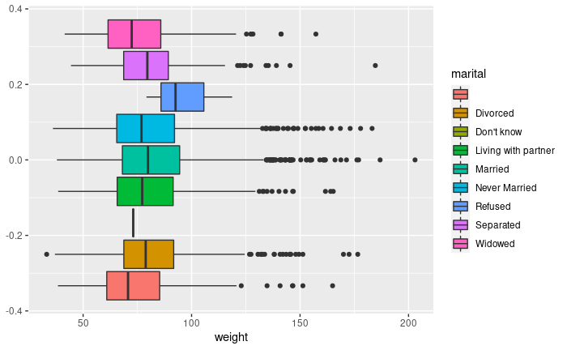

```r
ggplot(bodymeas) + geom_boxplot(aes(x = weight, fill = marital))
```

```r
#ggplot(bodymeas) +
#  geom_boxplot(aes(x = reorder(weight, marital), fill = marital))
```

### Discrete Variables with Many Values

What happens if you try to get an idea of the ages of individuals represented in our `bodymeas` data?

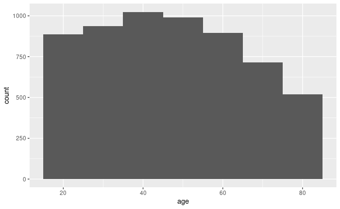

```r
ggplot(bodymeas) + geom_histogram(aes(x = age), binwidth = 10)
```

Find a way to create a chart of ages broken down by the decade of age (i.e. ages 50, 51, 52, … 59 would all just be considered 50 (for the 50’s decade))

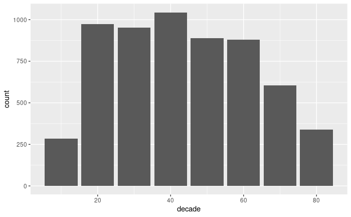

```r
bodymeas %>% mutate(decade = (age %/% 10) * 10) %>% group_by(decade) %>% summarize(count = n()) %>% ggplot() +
  geom_col(aes(x = decade, y = count))
```

## Looking for Variation/Relations Between Variables (Covariation)

### Between Categorical and Continuous Variables

We’ve played with this a good bit with `ggplot()`, we can break out a continuous variable by categorical value. Use the `coasters` data frame to get an idea of the top speed of roller coasters based on the type of construction?

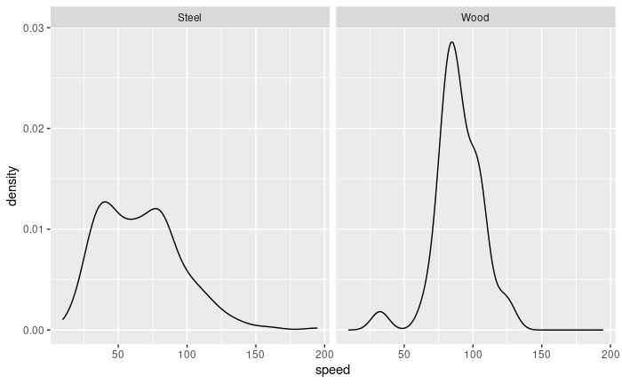

```r
ggplot(coasters) + geom_density(aes(x = speed)) + facet_wrap(~construction)
```

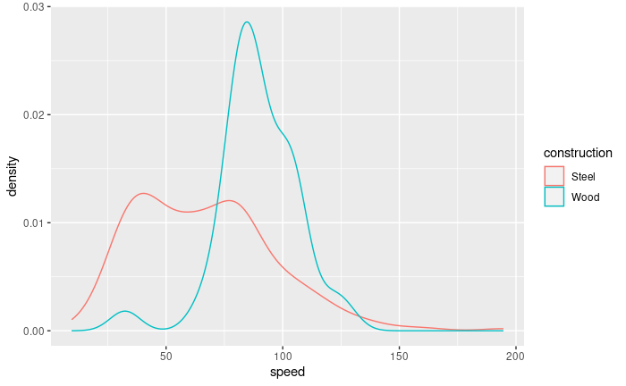

```r
ggplot(coasters) + geom_density(aes(x = speed, color = construction))
```

### Between Categorical and Categorical Variables

Use the `coasters` data set and use `geom_tiles()` to make a visualization of the average speed of roller coasters broken down by construction and number of inversions.

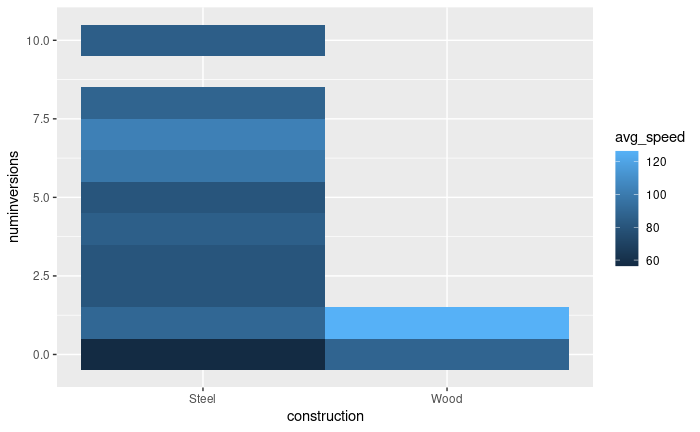

```r
coasters %>%
  group_by(construction, numinversions) %>%
  summarize(avg_speed = mean(speed, na.rm = TRUE)) %>%
ggplot() +
  geom_tile(aes(x = construction, y = numinversions, fill = avg_speed))
```

What about using this technique for visualizing the number of people in our `bodymeas` set based on `race` and `maritial` status?

### Between Continuous and Continuous Variables

Compare `bodymeas` tibble, compare height and uparmlength

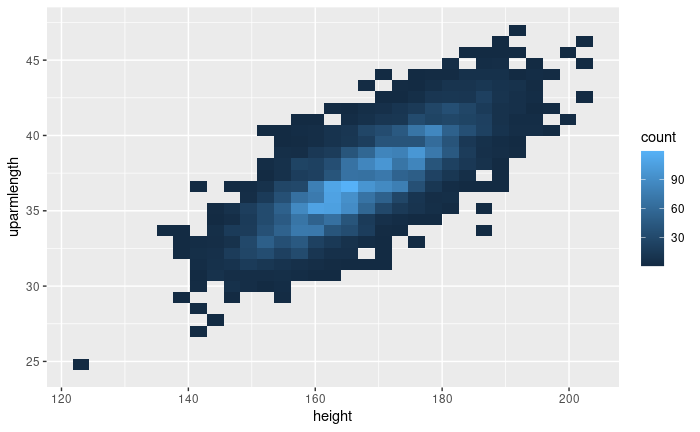

```r
ggplot(bodymeas) + geom_bin2d(aes(x = height, y = uparmlength))
```

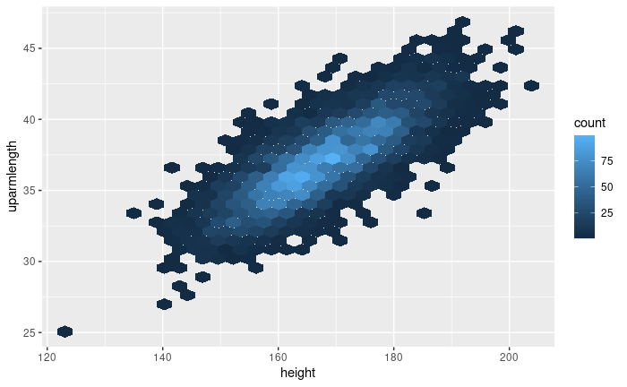

```r
ggplot(bodymeas) + geom_hex(aes(x = height, y = uparmlength))
```